# 181018_homework

강효진

2018년 10월 18일

- 데이터 : 서울시 보육시설 동별 통계 및 서울시 어린이 보호구역 통계
1. 관심 자료에 대해 summary를 하고, 집단별로 나눠서 min, max, mean, sd를 구해 보세요.
- 데이터 전처리

```r
library(readxl)
library(dplyr)

#데이터 불러오기
facility <- read_excel("서울시 보육시설 동별 통계.xlsx")
protection <- read_excel("서울시 어린이 보호구역 지정 현황.xlsx")

#변수명 바꾸기 (함수 실행시 오류 예방)
facility <- rename(facility, "법인단체" = "법인·단체 등")

#변수타입 문자형에서 숫자형으로 전환
facility <- transform(facility, 국공립 = as.numeric(국공립),
          사회복지법인 = as.numeric(사회복지법인),
          법인단체 = as.numeric(법인단체),
          민간 = as.numeric(민간),
          가정 = as.numeric(가정),
          부모협동 = as.numeric(부모협동),
          직장 = as.numeric(직장))

#0이 결측치로 처리되는 문제 해결
facility[is.na(facility[, "국공립"]), "국공립"] <- 0
facility[is.na(facility[, "사회복지법인"]), "사회복지법인"] <- 0
facility[is.na(facility[, "법인단체"]), "법인단체"] <- 0
facility[is.na(facility[, "민간"]), "민간"] <- 0
facility[is.na(facility[, "가정"]), "가정"] <- 0
facility[is.na(facility[, "부모협동"]), "부모협동"] <- 0
facility[is.na(facility[, "직장"]), "직장"] <- 0

head(facility)
```

```
##   자치구     동 국공립 사회복지법인 법인단체 민간 가정 부모협동 직장
## 1 종로구 사직동      1            1        0    1    0        0    9
## 2 종로구 삼청동      1            0        0    0    0        0    0
## 3 종로구 부암동      2            0        0    0    0        0    1
## 4 종로구 평창동      1            0        0    1    2        0    0
## 5 종로구 무악동      2            0        0    1    1        0    0
## 6 종로구 교남동      1            0        0    1    0        0    0
```

- Summary / max / min / mean / sd

```r
summary(facility)
```

```
##     자치구               동                국공립        사회복지법인
##  Length:423         Length:423         Min.   : 0.000   Min.   :0.00000
##  Class :character   Class :character   1st Qu.: 2.000   1st Qu.:0.00000
##  Mode  :character   Mode  :character   Median : 2.000   Median :0.00000
##                                        Mean   : 3.012   Mean   :0.07565
##                                        3rd Qu.: 4.000   3rd Qu.:0.00000
##                                        Max.   :15.000   Max.   :2.00000
##     법인단체           민간             가정           부모협동
##  Min.   :0.0000   Min.   : 0.000   Min.   : 0.000   Min.   :0.00000
##  1st Qu.:0.0000   1st Qu.: 2.000   1st Qu.: 2.000   1st Qu.:0.00000
##  Median :0.0000   Median : 4.000   Median : 4.000   Median :0.00000
##  Mean   :0.2742   Mean   : 4.584   Mean   : 6.128   Mean   :0.06856
##  3rd Qu.:0.0000   3rd Qu.: 7.000   3rd Qu.: 8.000   3rd Qu.:0.00000
##  Max.   :4.0000   Max.   :25.000   Max.   :42.000   Max.   :3.00000
##       직장
##  Min.   : 0.0000
##  1st Qu.: 0.0000
##  Median : 0.0000
##  Mean   : 0.5768
##  3rd Qu.: 1.0000
##  Max.   :22.0000
```

```r
facility %>%
  group_by(자치구) %>%
  summarise(mean = mean(국공립)) %>%
  arrange(desc(mean)) %>%
  head(5)
```

```
## # A tibble: 5 x 2
##   자치구    mean
##   <chr>    <dbl>
## 1 금천구    4.5
## 2 성동구    4.12
## 3 구로구    4
## 4 동대문구  3.93
## 5 마포구    3.88
```

```r
facility %>%
  group_by(자치구) %>%
  summarise(max = max(국공립)) %>%
  arrange(desc(max)) %>%
  head(5)
```

```
## # A tibble: 5 x 2
##   자치구   max
##   <chr>  <dbl>
## 1 구로구    15
## 2 양천구    15
## 3 강남구    12
## 4 강북구    11
## 5 강서구    10
```

```r
facility %>%
  group_by(자치구) %>%
  summarise(min = min(국공립)) %>%
  arrange(desc(min)) %>%
  head(5)
```

```
## # A tibble: 5 x 2
##   자치구   min
##   <chr>  <dbl>
## 1 금천구     2
## 2 동작구     2
## 3 성동구     2
## 4 양천구     2
## 5 강남구     1
```

```r
facility %>%
  group_by(자치구) %>%
  summarise(sd = sd(국공립)) %>%
  arrange(desc(sd)) %>%
  head(5)
```

```
## # A tibble: 5 x 2
##   자치구    sd
##   <chr>  <dbl>
## 1 구로구  3.53
## 2 양천구  3.07
## 3 금천구  2.76
## 4 성동구  2.76
## 5 강북구  2.67
```

2. 집단별로 함수를 적용하는 방법을 활용하여 자료에서 새로운 사실을 발견해 보세요.

```r
#자치구별 분류, 보육시설 수를 모두 더하여 총계열을 만든 후, 지역별로 확인
facility <- facility %>%
  mutate(tot_sum = 국공립+사회복지법인+법인단체+민간+가정+부모협동+직장)

facility %>%
  group_by(자치구) %>%
  arrange(desc(tot_sum)) %>%
  head(5)
```

```
## # A tibble: 5 x 10
## # Groups:   자치구 [4]
##   자치구 동    국공립 사회복지법인 법인단체  민간  가정 부모협동  직장
##   <chr>  <chr>  <dbl>        <dbl>    <dbl> <dbl> <dbl>    <dbl> <dbl>
## 1 양천구 신정3동~     15            0        0     9    28        0     0
## 2 노원구 상계8동~      6            0        0     1    39        0     1
## 3 노원구 월계3동~      2            0        0     1    42        0     0
## 4 강남구 세곡동~     12            0        0     8    24        1     0
## 5 구로구 오류2동~     15            0        0     5    21        2     1
## # ... with 1 more variable: tot_sum <dbl>
```

```r
#자치구별 보육시설 수의 총합을 알 수 있음(많은 비중을 차지하고 있는 국공립, 가정 보육시설 순위와 다르게 나타나는 부분이 있음)
```

3. 두 개 이상의 자료를 통합(join)해서 하나의 큰 자료를 만들어 보세요.

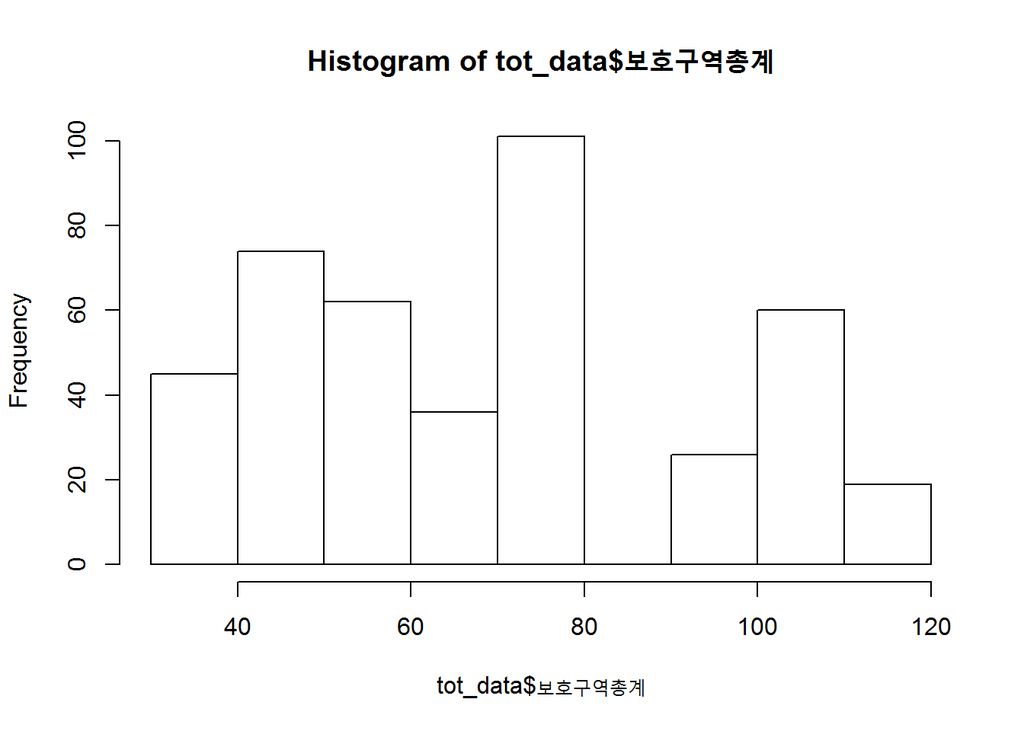

```r
#보호구역 데이터의 전처리 과정
data_p <- protection %>%
  group_by(시군구) %>%
  summarise(n = n()) #원데이터에는 보호구역의 수가 따로 나와있지 않기에, 빈도함수를 통해 보호구역 수를 알아봄

#데이터를 통합하기 위해 열 이름을 통일
data_p <- rename(data_p, "자치구" = "시군구")

#데이터 통합
tot_data <- full_join(facility , data_p , by="자치구")

#열이름을 알기쉽게 바꿈
tot_data <- rename(tot_data, "보육시설총계" = "tot_sum",
                   "보호구역총계" = "n")

hist(tot_data$보호구역총계)
```

```r
head(tot_data)
```

```
##   자치구     동 국공립 사회복지법인 법인단체 민간 가정 부모협동 직장
## 1 종로구 사직동      1            1        0    1    0        0    9
## 2 종로구 삼청동      1            0        0    0    0        0    0
## 3 종로구 부암동      2            0        0    0    0        0    1
## 4 종로구 평창동      1            0        0    1    2        0    0
## 5 종로구 무악동      2            0        0    1    1        0    0
## 6 종로구 교남동      1            0        0    1    0        0    0
##   보육시설총계 보호구역총계
## 1           12           46
## 2            1           46
## 3            3           46
## 4            4           46
## 5            4           46
## 6            2           46
```

4. 이 자료를 가로형, 세로형으로 형태를 바꿔 보세요.

```r
library(tidyr)

#세로형 데이터
longform <- tot_data %>%
  gather(보육시설, 보호구역총계, 국공립:직장, factor_key=TRUE)

longform2 <- tot_data %>%
  gather(종류, 갯수, 국공립:보호구역총계, factor_key=TRUE)
head(longform2)
```

```
##   자치구     동   종류 갯수
## 1 종로구 사직동 국공립    1
## 2 종로구 삼청동 국공립    1
## 3 종로구 부암동 국공립    2
## 4 종로구 평창동 국공립    1
## 5 종로구 무악동 국공립    2
## 6 종로구 교남동 국공립    1
```

```r
head(longform)
```

```
##   자치구     동 보육시설총계 보육시설 보호구역총계
## 1 종로구 사직동           12   국공립            1
## 2 종로구 삼청동            1   국공립            1
## 3 종로구 부암동            3   국공립            2
## 4 종로구 평창동            4   국공립            1
## 5 종로구 무악동            4   국공립            2
## 6 종로구 교남동            2   국공립            1
```

```r
#가로형 데이터
wideform <- spread(longform, 보육시설, 보호구역총계)
wideform2 <- spread(longform2, 종류, 갯수)
head(wideform)
```

```
##   자치구      동 보육시설총계 국공립 사회복지법인 법인단체 민간 가정
## 1 강남구 개포1동            8      1            0        0    2    5
## 2 강남구 개포2동            5      1            0        0    0    4
## 3 강남구 개포4동           18      3            0        0    8    6
## 4 강남구 논현1동            7      2            0        0    4    1
## 5 강남구 논현2동            5      1            0        0    2    0
## 6 강남구 대치1동            5      1            0        0    4    0
##   부모협동 직장
## 1        0    0
## 2        0    0
## 3        0    1
## 4        0    0
## 5        0    2
## 6        0    0
```

```r
head(wideform2)
```

```
##   자치구      동 국공립 사회복지법인 법인단체 민간 가정 부모협동 직장
## 1 강남구 개포1동      1            0        0    2    5        0    0
## 2 강남구 개포2동      1            0        0    0    4        0    0
## 3 강남구 개포4동      3            0        0    8    6        0    1
## 4 강남구 논현1동      2            0        0    4    1        0    0
## 5 강남구 논현2동      1            0        0    2    0        0    2
## 6 강남구 대치1동      1            0        0    4    0        0    0
##   보육시설총계 보호구역총계
## 1            8          103
## 2            5          103
## 3           18          103
## 4            7          103
## 5            5          103
## 6            5          103
```

## 채점 사항

> gather을 할 때, key, value 컬럼에 해당하는 컬럼의 이름을 정해 줘야 합니다. 그 후에 gather할 컬럼을 정해야 합니다. 결과는 비슷하지만 완벽하지 않았습니다.

```r
library(dplyr)
tot_data %>% filter(자치구 =="종로구", 동=="사직동")
```

```
##   자치구     동 국공립 사회복지법인 법인단체 민간 가정 부모협동 직장
## 1 종로구 사직동      1            1        0    1    0        0    9
##   보육시설총계 보호구역총계
## 1           12           46
```

```r
longform %>% filter(자치구 =="종로구", 동=="사직동")
```

```
##   자치구     동 보육시설총계     보육시설 보호구역총계
## 1 종로구 사직동           12       국공립            1
## 2 종로구 사직동           12 사회복지법인            1
## 3 종로구 사직동           12     법인단체            0
## 4 종로구 사직동           12         민간            1
## 5 종로구 사직동           12         가정            0
## 6 종로구 사직동           12     부모협동            0
## 7 종로구 사직동           12         직장            9
```

```r
wideform %>% filter(자치구 =="종로구", 동 =="사직동")
```

```
##   자치구     동 보육시설총계 국공립 사회복지법인 법인단체 민간 가정
## 1 종로구 사직동           12      1            1        0    1    0
##   부모협동 직장
## 1        0    9
```

```r
tot_data %>% filter(자치구 =="종로구", 동=="사직동")
```

```
##   자치구     동 국공립 사회복지법인 법인단체 민간 가정 부모협동 직장
## 1 종로구 사직동      1            1        0    1    0        0    9
##   보육시설총계 보호구역총계
## 1           12           46
```

```r
longform2 %>% filter(자치구 =="종로구", 동=="사직동")
```

```
##   자치구     동         종류 갯수
## 1 종로구 사직동       국공립    1
## 2 종로구 사직동 사회복지법인    1
## 3 종로구 사직동     법인단체    0
## 4 종로구 사직동         민간    1
## 5 종로구 사직동         가정    0
## 6 종로구 사직동     부모협동    0
## 7 종로구 사직동         직장    9
## 8 종로구 사직동 보육시설총계   12
## 9 종로구 사직동 보호구역총계   46
```

```r
wideform2 %>% filter(자치구 =="종로구", 동 =="사직동")
```

```
##   자치구     동 국공립 사회복지법인 법인단체 민간 가정 부모협동 직장
## 1 종로구 사직동      1            1        0    1    0        0    9
##   보육시설총계 보호구역총계
## 1           12           46
```